# BLAST

## Chromosomal locations

The goal of this analysis is to extract the chromosomal locations for all homologs identified. Notice that not all genomes from which these sequences came are well assembled. If the genome is not fully assembled to the chromosome level, the locations would not be meaningful.

> **Update 2021-06-17** The *C. auris* refseq strain, B11221, was assembled to the scaffold level on the NCBI Assembly database page. But according to Muñoz *et al.* 2021, the genome was basically assembled to the chromosomal level – the first 7 scaffolds are chromosomal length, with the remaining scaffolds being short and unassembled fragments. This means I can use the location information for this strain if the gene is located on the first seven scaffolds.

To determine the location on the chromosome, we need to know 1) the coordinate of the gene encoding the protein and 2) the length of the chromosome. Our approach to obtain these data depends upon the source of the sequences. For proteins identified through FungiDB and GRYC, since there are only a small number of them, I just manually searched and entered the information. For Refseq proteins, since it represents the majority of the data, and since the `rentrez` package allowed me to cross-reference information among the NCBI databases, I’ll attempt to gather the information programmatically.

1. Collect genome assembly information for all species/strains included in the Refseq dataset.

```r
# For all sequences with refseq IDs
# First get the genome assembly ID using the protein ID as query
refseq.strain <- unique(with(refseq1, paste(organism, strain, sep = " ")))
names(refseq.strain) <- word(refseq.strain, 1, 2)
refseq.strain["Naumovozyma castellii"] <- "Naumovozyma castellii CBS 4309"
refseq.strain["Candida glabrata"] <- "Candida glabrata 138" # for some reason the original query wouldn't retrieve the result
refseq.strain["Candida parapsilosis"] <- "ASM18276v2"       # using the species and strain name combo didn't retrieve the refseq assembly
# fungidb didn't add any new species that refseq hits didn't already have
gryc.strain <- unique(gryc1$species)
names(gryc.strain) <- word(gryc.strain, 1, 2)
gryc.strain["Kluyveromyces lactis"] <- "ASM251v1"           # this is the NCBI Assembly for K. lactis NRRL Y-1140, not the GRYC CBS 2359, but we only had one sequence from this species and the sequence is identical to the refseq version from the NRRL strain
all.strain <- c(refseq.strain, gryc.strain)
tmp <- sapply(all.strain, function(i){
  #Sys.sleep(1) # added to avoid the API rate limitation error
  entrez_search(db = "assembly", term = i, use_history = T)$ids
})
assembly.info <- sapply(tmp, function(i){
  if(!is_empty(i))
    entrez_summary(db = "assembly", id = i)
})
```

2. For species with chromosomal level assemblies, we can use the protein ID to fish out the chromosomal location and chromosome length information.

```r
# Get the protein's gene ID (not refseq ID)
tmp.gene.lnk <- entrez_link(dbfrom = "protein", id = refseq1$accession, db = "gene", by_id = TRUE)
# extract gene ID
tmp.gene.id <- sapply(tmp.gene.lnk, function(x) x$links$protein_gene)
# fetch summary info from the gene database
tmp.gene <- entrez_summary(db = "gene", id = tmp.gene.id)
# extract gene name
tmp.gene.name <- extract_from_esummary(tmp.gene, elements = "name")
# extract systematic ID (stored in the otheralias field)
tmp.gene.alias <- extract_from_esummary(tmp.gene, elements = "otheraliases")
# extract chromosomal locations, only available for fully assembled genomes
tmp.gene.loc <- bind_rows(extract_from_esummary(tmp.gene, elements = "genomicinfo"), .id = "gene_uid")
# pool the unique chromosome sequence IDs to find out their length
tmp.chr.id <- unique(tmp.gene.loc$chraccver)
# obtain the chromosome length information from the nuccore database
tmp.chr <- entrez_summary("nuccore", id = tmp.chr.id)
tmp.chr.len <- extract_from_esummary(tmp.chr, elements = "slen");
names(tmp.chr.len) = tmp.chr.id
# also get the assembly id
tmp.assembly.lnk <- entrez_link(dbfrom = "nuccore", id = tmp.chr.id, db = "assembly", by_id = T)
# some sequences map to more than one assembly. use the first one
tmp.assembly.id <- sapply(tmp.assembly.lnk, function(i) i$links$nuccore_assembly[1])
# 2021-06-18 for unknown reasons, one of the chromosomes failed to get a link even though
#   searches on the NCBI website gives the expected result. Manually add it in
# tmp.assembly.id[[8]] <- "277478"
tmp.assembly <- map_chr(tmp.assembly.id, function(x)
  entrez_summary(db = "assembly", id = x)$assemblyaccession)
names(tmp.assembly) <- tmp.chr.id
# construct a new tibble to hold the chromosomal location info
refseq2 <- refseq1 %>%
  select(accession, species, organism) %>%
  mutate(gene_uid = names(tmp.gene.name), gene_id = tmp.gene.name, alias = tmp.gene.alias) %>%
  left_join(tmp.gene.loc, by = c("gene_uid" = "gene_uid")) %>%
  mutate(assembly = tmp.assembly[chraccver], chrL = tmp.chr.len[chraccver],
         relLoc = round(chrstart/chrL,2)) %>%
  select(-exoncount)
```

```r
# since some species are fully assembled while others are not, let's split them into two and deal with the latter separately
refseq2s <- group_split(refseq2, is.na(chraccver), .keep = FALSE)
# print the ones successfully assembled
refseq2s[[1]] %>% select(-gene_uid, -chraccver) %>% arrange(species, relLoc)
```

| accession | species | organism | gene_id | alias | chrloc | chrstart | chrstop | assembly | chrL | relLoc |
| --- | --- | --- | --- | --- | --- | --- | --- | --- | --- | --- |
| XP_717775.2 | Candida albicans | Candida albicans | FLO9 | CAALFM_C300580WA | 3 | 88911 | 92646 | GCF_000182965.3 | 1799298 | 0.05 |
| XP_717774.1 | Candida albicans | Candida albicans | IFF11 | CAALFM_C300600WA | 3 | 95651 | 97186 | GCF_000182965.3 | 1799298 | 0.05 |
| XP_718630.1 | Candida albicans | Candida albicans | IFF4 | CAALFM_CR00610WA | R | 145022 | 149602 | GCF_000182965.3 | 2286237 | 0.06 |
| XP_717969.1 | Candida albicans | Candida albicans | HYR4 | CAALFM_CR00760CA | R | 181468 | 177791 | GCF_000182965.3 | 2286237 | 0.08 |
| XP_714203.1 | Candida albicans | Candida albicans | HYR3 | CAALFM_C500730WA | 5 | 171022 | 174771 | GCF_000182965.3 | 1190845 | 0.14 |
| XP_714201.2 | Candida albicans | Candida albicans | IFF8 | CAALFM_C500710WA | 5 | 164507 | 166651 | GCF_000182965.3 | 1190845 | 0.14 |
| XP_715137.2 | Candida albicans | Candida albicans | IFF3 | CAALFM_CR03630WA | R | 804769 | 807594 | GCF_000182965.3 | 2286237 | 0.35 |
| XP_717330.2 | Candida albicans | Candida albicans | IFF9 | CAALFM_CR03880WA | R | 866453 | 869278 | GCF_000182965.3 | 2286237 | 0.38 |
| XP_711686.2 | Candida albicans | Candida albicans | RBR3 | CAALFM_C703290CA | 7 | 721384 | 716696 | GCF_000182965.3 | 949511 | 0.76 |
| XP_714246.2 | Candida albicans | Candida albicans | IFF6 | CAALFM_C209130CA | 2 | 1869112 | 1865855 | GCF_000182965.3 | 2231883 | 0.84 |

[output cut: 23 more lines]

Above are the ones that we can find the chromosomal information for.

3. Next let’s deal with the partially assembled genomes. The idea is to first download the genome annotation files for the species/strains and then extract the genomic information from them. Because some species/strain could have multiple assemblies, we need to collect all of them and then identify the latest / representative one. I found that each species/strain has only one assembly that has the “refseq” status. Therefore I chose that as the representative assembly.

Below are all the species in our dataset, followed by the corresponding refseq assembly.

```r
# 1. List the unique species in the dataset
sps.list <- names(all.strain)
sps.list
```

```
 [1] "Candida pseudohaemulonii"  "Candida parapsilosis"      "Candida tropicalis"
 [4] "Debaryomyces hansenii"     "Candida albicans"          "Clavispora lusitaniae"
 [7] "Candida auris"             "Candida haemuloni"         "Candida duobushaemulonis"
[10] "Scheffersomyces stipitis"  "Candida dubliniensis"      "Lodderomyces elongisporus"
[13] "Naumovozyma castellii"     "Candida glabrata"          "Nakaseomyces delphensis"
[16] "Kluyveromyces lactis"      "Nakaseomyces bracarensis"  "Nakaseomyces nivariensis"
```

```r
# 2. Obtain assembly information
## explanation for the fields from the assembly record: https://www.ncbi.nlm.nih.gov/assembly/help/
## to parse information from the "meta" field, which is in XML format, I used the "XML" package
## and to access particular nodes from the object, I used the syntax as specified for XPatH
## reference: https://www.w3schools.com/xml/xpath_syntax.asp
sps.stat <- tibble(species = character(), strain = character(),  assemblyaccession = character(),
                   assemblyname = character(), assemblystatus = character(),
                   n_chr = integer(), n_scaffold = integer(), n_contig = integer(),
                   lastupdate = character(), submitter = character(),
                   refseq = character(), ftpreport = character())

for(s in sps.list){
  ss <- assembly.info[[s]]
  if(class(ss)[1] == "esummary"){
    # some strains have just one assembly
    # most of the information are easily accessible as elements of the list
    # for the # of contigs and # of scaffolds, however, I need to parse the XML formatted "extra" field
    f = newXMLNode("assembly")
    parseXMLAndAdd(ss$meta, f)
    n.chr = getNodeSet(f, "//Stat[@category='chromosome_count']") %>% xmlValue %>% as.integer
    n.scaffold = getNodeSet(f, "//Stat[@category='scaffold_count' and @sequence_tag='all']") %>% xmlValue %>% as.integer
    n.contig = getNodeSet(f, "//Stat[@category='contig_count']") %>% xmlValue %>% as.integer
    tmp.strain = ss$biosource$infraspecieslist$sub_value
    sps.stat <- sps.stat %>%
      add_row(species = s, strain = ifelse(is.null(tmp.strain), ss$biosource$isolate, tmp.strain),
              assemblyaccession = ss$assemblyaccession, assemblyname = ss$assemblyname, assemblystatus = ss$assemblystatus,
              n_chr = n.chr, n_scaffold = n.scaffold, n_contig = n.contig,
              lastupdate = ss$lastupdatedate, submitter = ss$submitterorganization,
              refseq = ss$refseq_category, ftpreport = ss$ftppath_assembly_rpt)
  }else if(class(ss)[1] == "esummary_list"){
    # some strains have more than one assembly and we iterate through them
    ss0 = ss
    for(ss in ss0){
      f = newXMLNode("assembly")
      parseXMLAndAdd(ss$meta, f)
      n.chr = getNodeSet(f, "//Stat[@category='chromosome_count']") %>% xmlValue %>% as.integer
      n.scaffold = getNodeSet(f, "//Stat[@category='scaffold_count' and @sequence_tag='all']") %>% xmlValue %>% as.integer
      n.contig = getNodeSet(f, "//Stat[@category='contig_count']") %>% xmlValue %>% as.integer
      sps.stat <- sps.stat %>%
        add_row(species = s, strain = ss$biosource$infraspecieslist$sub_value,
                assemblyaccession = ss$assemblyaccession, assemblyname = ss$assemblyname, assemblystatus = ss$assemblystatus,
                n_chr = n.chr, n_scaffold = n.scaffold, n_contig = n.contig,
                lastupdate = ss$lastupdatedate, submitter = ss$submitterorganization,
                refseq = ss$refseq_category, ftpreport = ss$ftppath_assembly_rpt)
    }
  }
}

sps.stat <- sps.stat %>%
  mutate(n_chr = ifelse(n_chr <= 1, NA, n_chr),
         n_scaffold = ifelse(n_scaffold <= 1, NA, n_scaffold),
         n_contig = ifelse(n_contig <= 0, NA, n_contig))

sps.stat %>% filter(refseq != "na") %>% select(-assemblyaccession, -assemblyname, -ftpreport, -refseq) %>% arrange(assemblystatus)
```

| species | strain | assemblystatus | n_chr | n_scaffold | n_contig | lastupdate | submitter |
| --- | --- | --- | --- | --- | --- | --- | --- |
| Debaryomyces hansenii | CBS767 | Chromosome | 7 | 8 | 15 | 2014/02/07 00:00 | Genolevures Consortium |
| Candida albicans | SC5314 | Chromosome | 8 | 8 | 88 | 2016/12/08 00:00 | Stanford University |
| Scheffersomyces stipitis | CBS 6054 | Chromosome | 8 | 8 | 9 | 2016/11/29 00:00 | DOE Joint Genome Institute |
| Naumovozyma castellii | type strain:CBS 4309 | Chromosome | 10 | 10 | 17 | 2017/07/25 00:00 | Wolfe Laboratory, Smurfit Institute of Genetics, Trinity College Dublin |
| Candida glabrata | CBS 138 | Chromosome | 13 | 14 | 17 | 2017/06/05 00:00 | Genolevures Consortium |
| Candida dubliniensis | CD36 | Complete Genome | 8 | 8 | 8 | 2017/12/13 00:00 | Wellcome Trust Sanger Institute |
| Kluyveromyces lactis | NRRL Y-1140 | Complete Genome | 6 | 7 | 7 | 2012/10/15 00:00 | Genolevures Consortium |
| Candida parapsilosis | CDC317 | Contig | NA | 9 | 9 | 2020/10/30 00:00 | Wellcome Trust Sanger Institute |
| Candida haemuloni | B11899 | Contig | NA | 12 | 12 | 2019/04/10 00:00 | Centers for Disease Control and Prevention |
| Candida duobushaemulonis | B09383 | Contig | NA | 8 | 8 | 2019/05/31 00:00 | Centers for Disease Control and Prevention |

[output cut: 8 more lines]

Now that we have got the representative genome assemblies, we can use the ftppath to download the assembly information.

```r
ftpreport <- sps.stat %>% filter(refseq != "na") %>% pull(ftpreport)
ftpfeature <- gsub("_assembly_report.txt", "_feature_table.txt.gz", ftpreport)
for(f in c(ftpreport, ftpfeature)){
  destfile = paste0("data/assembly-info/",last(str_split(f, "/")[[1]]))
  # https://stackoverflow.com/questions/14904983/how-do-i-check-the-existence-of-a-downloaded-file
  if(!file.exists(destfile)){
    tryCatch(download.file(f, destfile), error = function(e) 1)
  }
}
```

Note that three genomes do not have feature tables at the time of downloading (2021-02-04). They are: Nakaseomyces delphensis CBS 2170, Nakaseomyces bracarensis CBS 10154, Nakaseomyces nivariensis CBS 9983.

Instead of loading all the tables, I found it is easier to just search through them using `grep`. The idea is to iterate through the `refseq2s[[2]]`, which contains all the proteins with undetermined locations. For each entry, search the gene ID against the feature tables using `zgrep` and capture the output.

```r
search_chr_loc <- function(gene){
  cmd <- sprintf("zgrep %s data/assembly-info/*feature_table.txt.gz | grep ':gene'", gene)
  res <- system(cmd, intern = TRUE)
  if(length(res) > 1){
    stop(sprintf('More than one record found for "%s"', gene))
  }else if(length(res) == 0){
    return(NA)
  }
  gInfo <- str_split(res, "\t")[[1]]
  # 1: file name; 3: assembly name; 7: "chromosome" name; 8: start; 9: end; 10: strand; 17: gene ID; 18: gene length
  assembly.file <- gsub("feature_table.txt.gz:gene", "assembly_report.txt", gInfo[1])
  res1 <- system(paste("grep",gInfo[7],assembly.file), intern = TRUE)
  if(length(res1) > 1)
    stop(sprintf('More than one record found for "%s"', gene[7]))
  chr <- str_split(res1, "\t")[[1]]
  # 1: seq_name; 7: refseq_acc; 9: length
  final <- tibble(gene_id = gene, assembly = gInfo[3], chrloc = chr[1], chraccver = gInfo[7],
                  chrstart = gInfo[8], chrstop = gInfo[9], chrL = chr[9])
  return(final)
}
```

```r
tmp1 <- map_dfr(refseq2s[[2]]$gene_id, search_chr_loc)
tmp1 <- tmp1 %>%
  mutate(chrstart = as.integer(chrstart), chrstop = as.integer(chrstop), chrL = as.integer(chrL),
         relLoc = round(chrstart/chrL, 2))
```

Update the original table

```r
refseq2s[[2]] <- rows_update(refseq2s[[2]], tmp1, by = "gene_id")
refseq3 <- bind_rows(refseq2s)
```

4. Let’s do the same search with the FungiDB hits. GRYC has no matches since none of the GRYC strains are in the NCBI assembly database.

```r
tmp2 <- map_dfr(fdb.list[-2], search_chr_loc) # the B9J08 sequence is ignored since its genome is not the refseq assembly
tmp2 <- tmp2 %>%
  rename(chr_name = chrloc) %>%
  mutate(chrstart = as.integer(chrstart), chrstop = as.integer(chrstop),
         chrL = as.integer(chrL), relLoc = round(chrstart/chrL, 2))
```

> The B9J08 sequence is the missing homolog from B11221. As shown in the README.md of this blast folder, I found that the “missing homolog” is actually present, but was broken into two fragments due to incomplete assembly. The C-terminus of the B9J08 sequence aligns to a fragment NW_021640165.1, which corresponds to scaffold00001. Its length is 4,303,397 bp, which is nearly the same as the reported chromosome 1 length from Muñoz *et al*. 2021 (Fig. 1). I therefore believe that this homolog (Hil4) is located at the 3’ tip of chromosome 1 of B11221.
5. Finally, we can combine the above results with the manually entered GRYC results

```r
non.refseq <- read_tsv("data/GRYC/XP_028889033_homologs_chr_loc_fungidb_gryc.txt", comment = "#") %>%
  rows_update(tmp2, by = "gene_id") # update the list with the search results above for the fungidb ones
# decide the tibble structure:
# accession (for protein from source); source: GRYC/FungiDB/Refseq; species; species_id; strain
# assembly; assemblystatus; n_seqs; gene_id; gene_name; chraccver; chr_name; chrstart, chrstop;
# chrL; relLoc
refseq4 <- refseq3 %>%
  rename(gene_id = alias, gene_name = gene_id, chr_name = chrloc) %>%
  left_join(sps.stat %>% filter(refseq !=  "na") %>%
              select(organism = species, strain, assembly = assemblyaccession, assemblystatus, starts_with("n_")),
            by = c("organism", "assembly")) %>%
  mutate(source = "Refseq", species_id = paste0(substr(species,1,1),word(species, 2, 2)),
         # https://stackoverflow.com/questions/28070878/r-use-min-within-dplyrmutate
         n_seqs = pmin(n_chr, n_scaffold, n_contig, na.rm = T)) %>%
  select(source, accession, species, species_id, strain, assembly, assemblystatus, n_seqs, gene_id, gene_name,
         chraccver, chr_name, chrstart, chrstop, chrL, relLoc)
all.genes <- bind_rows(refseq4, non.refseq)
write_tsv(all.genes, "output/XP_028889033_homologs_chr_loc.tsv")
```

## Evaluate e-value cutoff

Jan asked whether the 1e-5 cutoff is too liberal such that some of the hits that just “made the cut” may be false positives. I decide to look into this by highlighting those sequences in the alignment, and to examine their features such as protein length and annotated functions.

```r
# Identify the subset with E-value between 1e-5 to 1e-10
refseq.highE <- refseq1 %>% filter(-log10(e.value) < 10); refseq.highE
```

|  | accession | species | species_id | organism | strain | description | max.score | total.score | query.cover | e.value | perc.ident | length |
| --- | --- | --- | --- | --- | --- | --- | --- | --- | --- | --- | --- | --- |
| 1111955565 | XP_717775.2 | Candida albicans | Calbicans | Candida albicans | SC5314 | LOW QUALITY PROTEIN: FLO9p [Candida albicans SC5314] | 68.9 | 68.9 | 58 | 9e-09 | 27.31 | 1244 |
| 260939630 | XP_002614115.1 | Clavispora lusitaniae | Clusitaniae | Clavispora lusitaniae | ATCC 42720 | hypothetical protein CLUG_05601 [Clavispora lusitaniae ATCC 42720] | 67.0 | 67.0 | 76 | 3e-08 | 30.33 | 780 |
| 255725956 | XP_002547904.1 | Candida tropicalis | Ctropicalis | Candida tropicalis | MYA-3404 | predicted protein [Candida tropicalis MYA-3404] | 72.4 | 72.4 | 56 | 2e-09 | 28.02 | 1038 |
| 260941297 | XP_002614815.1 | Clavispora lusitaniae | Clusitaniae | Clavispora lusitaniae | ATCC 42720 | hypothetical protein CLUG_05593 [Clavispora lusitaniae ATCC 42720] | 70.9 | 70.9 | 56 | 5e-09 | 26.84 | 674 |
| 302309776 | XP_447567.2 | Candida glabrata | Cglabrata | Candida glabrata | CBS 138 | uncharacterized protein CAGL0I07293g [[Candida] glabrata] | 68.9 | 68.9 | 51 | 3e-08 | 28.31 | 1771 |
| 260939640 | XP_002614120.1 | Clavispora lusitaniae | Clusitaniae | Clavispora lusitaniae | ATCC 42720 | hypothetical protein CLUG_05606 [Clavispora lusitaniae ATCC 42720] | 65.1 | 65.1 | 56 | 3e-07 | 26.67 | 624 |
| 50287095 | XP_445977.1 | Candida glabrata | Cglabrata | Candida glabrata | CBS 138 | uncharacterized protein CAGL0E06600g [[Candida] glabrata] | 63.2 | 63.2 | 55 | 2e-06 | 28.36 | 965 |

```r
fdb.highE    <- fungidb %>% filter(gene_id %in% fdb.list, -log10(e_value) < 10); fdb.highE
```

| gene_id | source_id | organism | score | e_value | entrez_id | product_description | orthologgroup | length | pfam_id | pfam_description | species_id |
| --- | --- | --- | --- | --- | --- | --- | --- | --- | --- | --- | --- |
| CLUG_05233 | CLUG_05233-t34_1 | Clavispora lusitaniae ATCC 42720 | 60.5 | 6e-09 | 8495402 | hypothetical protein | OG6_127329 | 1442 | PF11765 | Hyphally regulated cell wall protein N-terminal | Clusitaniae |
| CPAR2_600430 | CPAR2_600430-T | Candida parapsilosis CDC317 | 59.7 | 1e-08 | N/A | Ortholog of Debaryomyces hansenii CBS767 : DEHA2C12716g | OG6_109478 | 1429 | PF04886;PF11765 | PT repeat;Hyphally regulated cell wall protein N-terminal | Cparapsilosis |
| CPAR2_806420 | CPAR2_806420-T | Candida parapsilosis CDC317 | 62.4 | 2e-09 | N/A | Ortholog(s) have role in cell morphogenesis involved in conjugation with cellular fusion and cell surface, fungal-type cell wall, mating projection localization | OG6_113672 | 1714 | PF11765 | Hyphally regulated cell wall protein N-terminal | Cparapsilosis |

```r
gryc.highE   <- gryc %>% filter(id %in% gryc1$id, -log10(min_e_value) < 10); gryc.highE
```

| id | ori_id | species | description | length | max_bit_score | query_cover | min_e_value | max_ident | species_id |
| --- | --- | --- | --- | --- | --- | --- | --- | --- | --- |
| XP_452176.1 | KLLA0B14498g1_1 | Kluyveromyces lactis CBS 2359 | conserved hypothetical protein | 766 | 63.5 | 61.277 | 9e-10 | 27.628 | Klactis |
| CABR0s21e03234g | BN119_CABR0s21e03234g1_1 | Nakaseomyces bracarensis CBS 10154 | weakly similar to uniprot\|Q6FUW7 Candida glabrata CAGL0E06600g | 892 | 55.5 | 63.473 | 3e-07 | 27.545 | Nbracarensis |
| CANI0s04e00110g | BN122_CANI0s04e00110g1_1 | Nakaseomyces nivariensis CBS 9983 | weakly similar to uniprot\|Q6FUW7 Candida glabrata CAGL0E06600g | 918 | 51.2 | 58.882 | 7e-06 | 28.616 | Nnivariensis |

```r
# get the subset of sequences
highE.seq <- c(refseqdb.seq[refseq.highE$accession], fungidb.seq[fdb.highE$gene_id],
               gryc.seq[gryc.highE$ori_id])
highE.names <- c(paste(refseq.highE$accession, refseq.highE$species_id, sep = "_"),
                 paste(fdb.highE$gene_id, fdb.highE$species_id, sep = "_"),
                 paste(gryc.highE$ori_id, gryc.highE$species_id, sep = "_"))
write.fasta(highE.seq, names = highE.names,
            file.out = "output/XP_028889033_homologs_high_Evalue.fasta")
```

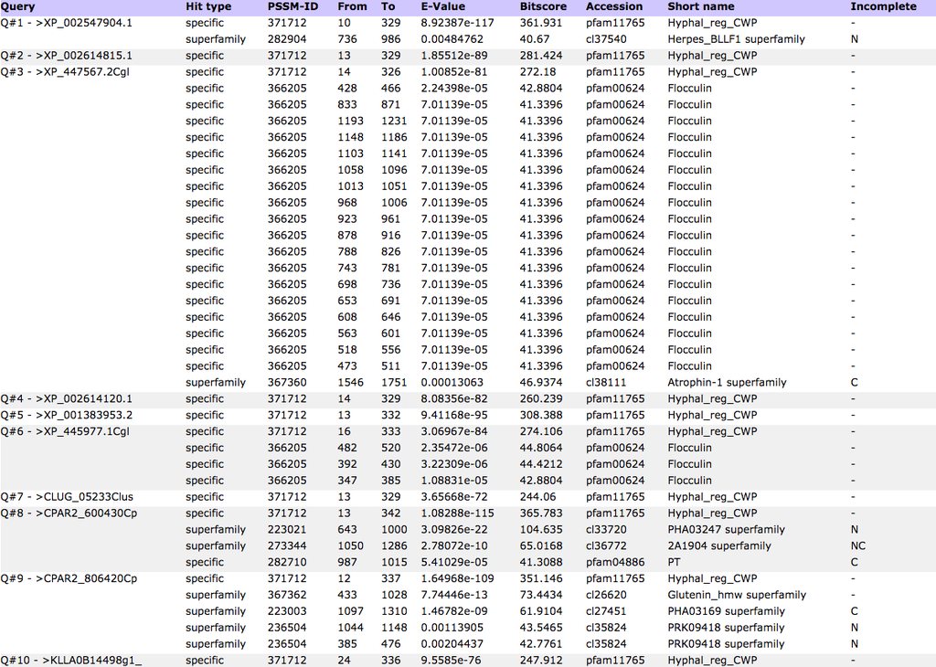

We can see that all of them have the Hyphally regulated cell wall protein (Hyphal_reg_CWP) domain. Therefore I believe they are true homologs to XP_028889033. Below is the multiple sequence alignment in which I moved all the sequences with e-value > 1e-10 to the top. We can see that while they are more divergent from the rest of the sequences, the alignment appears to be credible.

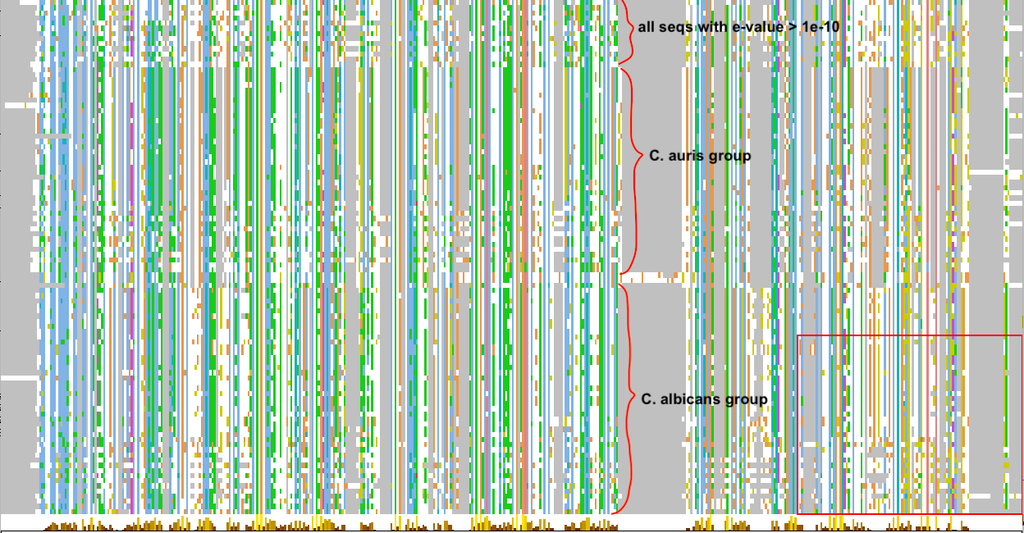

sequence alignments with e-value > 1e-10